# Introduction

Do higher film budgets lead to more box office revenue? Let's find out if there's a relationship using the movie budgets and financial performance data that I've scraped from [the-numbers.com](https://www.the-numbers.com/movie/budgets) on **May 1st, 2018**.

[figure not shown]

# Import Statements

```python
import pandas as pd
import matplotlib.pyplot as plt
```

# Notebook Presentation

```python
pd.options.display.float_format = '{:,.2f}'.format

from pandas.plotting import register_matplotlib_converters
register_matplotlib_converters()
```

# Read the Data

```python
data = pd.read_csv('cost_revenue_dirty.csv')
```

# Explore and Clean the Data

**Challenge**: Answer these questions about the dataset:

1. How many rows and columns does the dataset contain?
2. Are there any NaN values present?
3. Are there any duplicate rows?
4. What are the data types of the columns?

```python
data.shape
```

```
(5391, 6)
```

```python
data.info()
```

```
<class 'pandas.core.frame.DataFrame'>
RangeIndex: 5391 entries, 0 to 5390
Data columns (total 6 columns):
 #   Column                 Non-Null Count  Dtype
---  ------                 --------------  -----
 0   Rank                   5391 non-null   int64
 1   Release_Date           5391 non-null   object
 2   Movie_Title            5391 non-null   object
 3   USD_Production_Budget  5391 non-null   object
 4   USD_Worldwide_Gross    5391 non-null   object
 5   USD_Domestic_Gross     5391 non-null   object
dtypes: int64(1), object(5)
memory usage: 252.8+ KB
```

```python
data.isna().values.any()
```

```
False
```

```python
data.duplicated().values.any()
```

```
False
```

```python
data.info()
```

```
<class 'pandas.core.frame.DataFrame'>
RangeIndex: 5391 entries, 0 to 5390
Data columns (total 6 columns):
 #   Column                 Non-Null Count  Dtype
---  ------                 --------------  -----
 0   Rank                   5391 non-null   int64
 1   Release_Date           5391 non-null   object
 2   Movie_Title            5391 non-null   object
 3   USD_Production_Budget  5391 non-null   object
 4   USD_Worldwide_Gross    5391 non-null   object
 5   USD_Domestic_Gross     5391 non-null   object
dtypes: int64(1), object(5)
memory usage: 252.8+ KB
```

```python
data.sample(5)
```

|  | Rank | Release_Date | Movie_Title | USD_Production_Budget | USD_Worldwide_Gross | USD_Domestic_Gross |
| --- | --- | --- | --- | --- | --- | --- |
| 4160 | 1473 | 5/18/2012 | What to Expect When You're Expecting | $37,500,000 | $120,925,697 | $41,152,203 |
| 4733 | 4513 | 11/14/2014 | Always Woodstock | $2,400,000 | $0 | $0 |
| 4406 | 46 | 6/21/2013 | Monsters University | $200,000,000 | $743,588,329 | $268,488,329 |
| 185 | 3921 | 12/25/1973 | The Sting | $5,500,000 | $159,616,327 | $159,616,327 |
| 4183 | 2756 | 6/29/2012 | People Like Us | $16,000,000 | $12,519,804 | $12,431,792 |

```python
chars_to_remove = ['$', ',']
columns_to_clean = ['USD_Production_Budget',
                    'USD_Worldwide_Gross',
                    'USD_Domestic_Gross']

for col in columns_to_clean:
    for char in chars_to_remove:
        data[col] = data[col].astype(str).str.replace(char,'')
    data[col] = pd.to_numeric(data[col])
```

```python
data.head()
```

|  | Rank | Release_Date | Movie_Title | USD_Production_Budget | USD_Worldwide_Gross | USD_Domestic_Gross |
| --- | --- | --- | --- | --- | --- | --- |
| 0 | 5293 | 8/2/1915 | The Birth of a Nation | 110000 | 11000000 | 10000000 |
| 1 | 5140 | 5/9/1916 | Intolerance | 385907 | 0 | 0 |
| 2 | 5230 | 12/24/1916 | 20,000 Leagues Under the Sea | 200000 | 8000000 | 8000000 |
| 3 | 5299 | 9/17/1920 | Over the Hill to the Poorhouse | 100000 | 3000000 | 3000000 |
| 4 | 5222 | 1/1/1925 | The Big Parade | 245000 | 22000000 | 11000000 |

### Data Type Conversions

**Challenge**: Convert the `USD_Production_Budget`, `USD_Worldwide_Gross`, and `USD_Domestic_Gross` columns to a numeric format by removing `$` signs and `,`.  
Note that *domestic* in this context refers to the United States.

**Challenge**: Convert the `Release_Date` column to a Pandas Datetime type.

```python
data['Release_Date'] = pd.to_datetime(data['Release_Date'])
```

```python
data.info()
```

```
<class 'pandas.core.frame.DataFrame'>
RangeIndex: 5391 entries, 0 to 5390
Data columns (total 6 columns):
 #   Column                 Non-Null Count  Dtype
---  ------                 --------------  -----
 0   Rank                   5391 non-null   int64
 1   Release_Date           5391 non-null   datetime64[ns]
 2   Movie_Title            5391 non-null   object
 3   USD_Production_Budget  5391 non-null   int64
 4   USD_Worldwide_Gross    5391 non-null   int64
 5   USD_Domestic_Gross     5391 non-null   int64
dtypes: datetime64[ns](1), int64(4), object(1)
memory usage: 252.8+ KB
```

```python
data.head()
```

|  | Rank | Release_Date | Movie_Title | USD_Production_Budget | USD_Worldwide_Gross | USD_Domestic_Gross |
| --- | --- | --- | --- | --- | --- | --- |
| 0 | 5293 | 1915-08-02 | The Birth of a Nation | 110000 | 11000000 | 10000000 |
| 1 | 5140 | 1916-05-09 | Intolerance | 385907 | 0 | 0 |
| 2 | 5230 | 1916-12-24 | 20,000 Leagues Under the Sea | 200000 | 8000000 | 8000000 |
| 3 | 5299 | 1920-09-17 | Over the Hill to the Poorhouse | 100000 | 3000000 | 3000000 |
| 4 | 5222 | 1925-01-01 | The Big Parade | 245000 | 22000000 | 11000000 |

### Descriptive Statistics

**Challenge**:

1. What is the average production budget of the films in the data set?
2. What is the average worldwide gross revenue of films?
3. What were the minimums for worldwide and domestic revenue?
4. Are the bottom 25% of films actually profitable or do they lose money?
5. What are the highest production budget and highest worldwide gross revenue of any film?
6. How much revenue did the lowest and highest budget films make?

```python
data.describe()
```

|  | Rank | USD_Production_Budget | USD_Worldwide_Gross | USD_Domestic_Gross |
| --- | --- | --- | --- | --- |
| count | 5,391.00 | 5,391.00 | 5,391.00 | 5,391.00 |
| mean | 2,696.00 | 31,113,737.58 | 88,855,421.96 | 41,235,519.44 |
| std | 1,556.39 | 40,523,796.88 | 168,457,757.00 | 66,029,346.27 |
| min | 1.00 | 1,100.00 | 0.00 | 0.00 |
| 25% | 1,348.50 | 5,000,000.00 | 3,865,206.00 | 1,330,901.50 |
| 50% | 2,696.00 | 17,000,000.00 | 27,450,453.00 | 17,192,205.00 |
| 75% | 4,043.50 | 40,000,000.00 | 96,454,455.00 | 52,343,687.00 |
| max | 5,391.00 | 425,000,000.00 | 2,783,918,982.00 | 936,662,225.00 |

```python
data[data.USD_Production_Budget == 42500000.00]
```

|  | Rank | Release_Date | Movie_Title | USD_Production_Budget | USD_Worldwide_Gross | USD_Domestic_Gross |
| --- | --- | --- | --- | --- | --- | --- |
| 3840 | 1245 | 2011-01-28 | The Mechanic | 42500000 | 76347393 | 29121498 |

```python
data[data.USD_Worldwide_Gross == 2783918982.00]
```

|  | Rank | Release_Date | Movie_Title | USD_Production_Budget | USD_Worldwide_Gross | USD_Domestic_Gross |
| --- | --- | --- | --- | --- | --- | --- |
| 3529 | 1 | 2009-12-18 | Avatar | 425000000 | 2783918982 | 760507625 |

# Investigating the Zero Revenue Films

**Challenge** How many films grossed $0 domestically (i.e., in the United States)? What were the highest budget films that grossed nothing?

```python
zero_rev = data[data.USD_Domestic_Gross == 0]
```

```python
zero_rev.count()
```

```
Rank                     512
Release_Date             512
Movie_Title              512
USD_Production_Budget    512
USD_Worldwide_Gross      512
USD_Domestic_Gross       512
dtype: int64
```

```python
zero_rev.USD_Production_Budget.max()
```

```
175000000
```

```python
zero_rev[zero_rev.USD_Production_Budget == 175000000]
```

|  | Rank | Release_Date | Movie_Title | USD_Production_Budget | USD_Worldwide_Gross | USD_Domestic_Gross |
| --- | --- | --- | --- | --- | --- | --- |
| 5388 | 96 | 2020-12-31 | Singularity | 175000000 | 0 | 0 |

**Challenge**: How many films grossed $0 worldwide? What are the highest budget films that had no revenue internationally?

```python
zero_rev_internation = data[data['USD_Worldwide_Gross'] == 0]
```

```python
zero_rev_internation.shape
```

```
(357, 6)
```

```python
zero_rev_internation.sort_values('USD_Production_Budget', ascending=False)
```

|  | Rank | Release_Date | Movie_Title | USD_Production_Budget | USD_Worldwide_Gross | USD_Domestic_Gross |
| --- | --- | --- | --- | --- | --- | --- |
| 5388 | 96 | 2020-12-31 | Singularity | 175000000 | 0 | 0 |
| 5387 | 126 | 2018-12-18 | Aquaman | 160000000 | 0 | 0 |
| 5384 | 321 | 2018-09-03 | A Wrinkle in Time | 103000000 | 0 | 0 |
| 5385 | 366 | 2018-10-08 | Amusement Park | 100000000 | 0 | 0 |
| 5058 | 880 | 2015-11-12 | The Ridiculous 6 | 60000000 | 0 | 0 |
| ... | ... | ... | ... | ... | ... | ... |
| 4787 | 5371 | 2014-12-31 | Stories of Our Lives | 15000 | 0 | 0 |
| 3056 | 5374 | 2007-12-31 | Tin Can Man | 12000 | 0 | 0 |
| 4907 | 5381 | 2015-05-19 | Family Motocross | 10000 | 0 | 0 |
| 5006 | 5389 | 2015-09-29 | Signed Sealed Delivered | 5000 | 0 | 0 |
| 5007 | 5390 | 2015-09-29 | A Plague So Pleasant | 1400 | 0 | 0 |

357 rows × 6 columns

### Filtering on Multiple Conditions

```python
international_releases = data.loc[(data.USD_Domestic_Gross == 0) &
                                  (data.USD_Worldwide_Gross != 0)]
international_releases.head()
```

|  | Rank | Release_Date | Movie_Title | USD_Production_Budget | USD_Worldwide_Gross | USD_Domestic_Gross |
| --- | --- | --- | --- | --- | --- | --- |
| 71 | 4310 | 1956-02-16 | Carousel | 3380000 | 3220 | 0 |
| 1579 | 5087 | 2001-02-11 | Everything Put Together | 500000 | 7890 | 0 |
| 1744 | 3695 | 2001-12-31 | The Hole | 7500000 | 10834406 | 0 |
| 2155 | 4236 | 2003-12-31 | Nothing | 4000000 | 63180 | 0 |
| 2203 | 2513 | 2004-03-31 | The Touch | 20000000 | 5918742 | 0 |

**Challenge**: Use the [`.query()` function](https://pandas.pydata.org/pandas-docs/stable/reference/api/pandas.DataFrame.query.html) to accomplish the same thing. Create a subset for international releases that had some worldwide gross revenue, but made zero revenue in the United States.

Hint: This time you'll have to use the `and` keyword.

```python
international_releases = data.query('USD_Domestic_Gross == 0 and USD_Worldwide_Gross !=0')
international_releases.tail()
```

|  | Rank | Release_Date | Movie_Title | USD_Production_Budget | USD_Worldwide_Gross | USD_Domestic_Gross |
| --- | --- | --- | --- | --- | --- | --- |
| 5340 | 1506 | 2017-04-14 | Queen of the Desert | 36000000 | 1480089 | 0 |
| 5348 | 2225 | 2017-05-05 | Chāi dàn zhuānjiā | 23000000 | 58807172 | 0 |
| 5360 | 4832 | 2017-07-03 | Departure | 1100000 | 27561 | 0 |
| 5372 | 1856 | 2017-08-25 | Ballerina | 30000000 | 48048527 | 0 |
| 5374 | 4237 | 2017-08-25 | Polina danser sa vie | 4000000 | 36630 | 0 |

### Unreleased Films

**Challenge**:

- Identify which films were not released yet as of the time of data collection (May 1st, 2018).
- How many films are included in the dataset that have not yet had a chance to be screened in the box office?
- Create another DataFrame called data_clean that does not include these films.

```python
# Date of Data Collection
scrape_date = pd.Timestamp('2018-5-1')
```

```python
data.sample(5)
```

|  | Rank | Release_Date | Movie_Title | USD_Production_Budget | USD_Worldwide_Gross | USD_Domestic_Gross |
| --- | --- | --- | --- | --- | --- | --- |
| 3876 | 2364 | 2011-04-11 | A Very Harold & Kumar 3D Christmas | 20000000 | 36265745 | 35061031 |
| 2292 | 4462 | 2004-09-07 | Riding Giants | 2600000 | 3292333 | 2276368 |
| 4439 | 1833 | 2013-08-03 | Dead Man Down | 30000000 | 19599974 | 10895295 |
| 4836 | 733 | 2015-02-27 | Focus | 65000000 | 154362963 | 53862963 |
| 2994 | 3822 | 2007-10-10 | Control | 6400000 | 8902141 | 871577 |

```python
data[data['Release_Date'] >= scrape_date]
```

|  | Rank | Release_Date | Movie_Title | USD_Production_Budget | USD_Worldwide_Gross | USD_Domestic_Gross |
| --- | --- | --- | --- | --- | --- | --- |
| 5384 | 321 | 2018-09-03 | A Wrinkle in Time | 103000000 | 0 | 0 |
| 5385 | 366 | 2018-10-08 | Amusement Park | 100000000 | 0 | 0 |
| 5386 | 2950 | 2018-10-08 | Meg | 15000000 | 0 | 0 |
| 5387 | 126 | 2018-12-18 | Aquaman | 160000000 | 0 | 0 |
| 5388 | 96 | 2020-12-31 | Singularity | 175000000 | 0 | 0 |
| 5389 | 1119 | 2020-12-31 | Hannibal the Conqueror | 50000000 | 0 | 0 |
| 5390 | 2517 | 2020-12-31 | Story of Bonnie and Clyde, The | 20000000 | 0 | 0 |

```python
data_clean = data[data['Release_Date'] <= scrape_date]
```

```python
total_movies = pd.to_numeric(data_clean.shape[0])
```

### Films that Lost Money

**Challenge**: What is the percentage of films where the production costs exceeded the worldwide gross revenue?

```python
lost_money_movies = len(data_clean[data_clean['USD_Production_Budget'] > data_clean['USD_Worldwide_Gross']])
```

```python
pecentage_lost_money = lost_money_movies/total_movies
```

```python
print(pecentage_lost_money)
```

```
0.37277117384843983
```

# Seaborn for Data Viz: Bubble Charts

```python
import seaborn as sns
```

### Plotting Movie Releases over Time

**Challenge**: Try to create the following Bubble Chart:

[figure not shown]

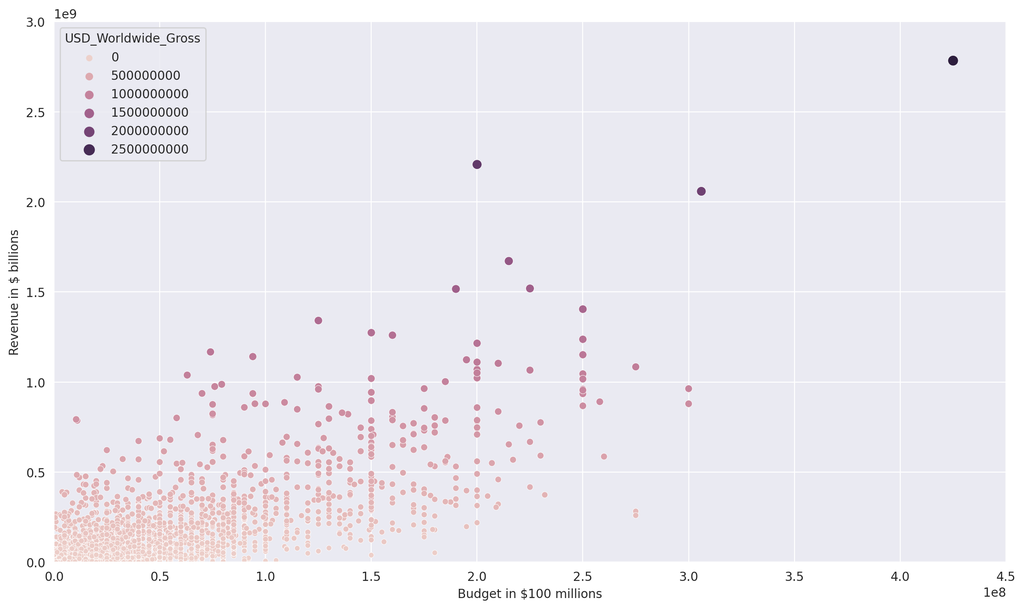

```python
plt.figure(figsize=(14,8), dpi=200)

with sns.axes_style('darkgrid'):
    ax = sns.scatterplot(data=data_clean,
                    x='USD_Production_Budget',
                    y='USD_Worldwide_Gross',
                    hue='USD_Worldwide_Gross',
                    size='USD_Worldwide_Gross')

    ax.set(ylim=(0, 3000000000),
        xlim=(0,450000000),
        ylabel='Revenue in $ billions',
        xlabel='Budget in $100 millions')

plt.show()
```

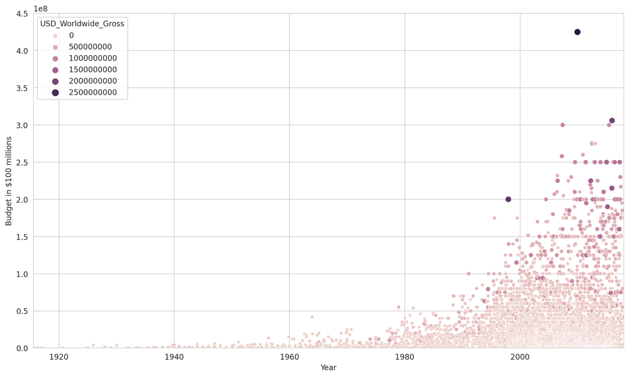

```python
plt.figure(figsize=(14,8), dpi=200)

with sns.axes_style('whitegrid'):
    ax = sns.scatterplot(data=data_clean,
                         x='Release_Date',
                         y='USD_Production_Budget',
                         hue='USD_Worldwide_Gross',
                         size='USD_Worldwide_Gross')
    ax.set(ylim=(0,450000000),
           xlim=(data_clean['Release_Date'].min(), data_clean['Release_Date'].max()),
           ylabel='Budget in $100 millions',
           xlabel='Year')

plt.show()
```

# Converting Years to Decades Trick

**Challenge**: Create a column in `data_clean` that has the decade of the release.

[figure not shown]

Here's how:

1. Create a [`DatetimeIndex` object](https://pandas.pydata.org/pandas-docs/stable/reference/api/pandas.DatetimeIndex.html) from the Release_Date column.
2. Grab all the years from the `DatetimeIndex` object using the `.year` property.

[figure not shown]

3. Use floor division `//` to convert the year data to the decades of the films.
4. Add the decades as a `Decade` column to the `data_clean` DataFrame.

```python
dt_index = pd.DatetimeIndex(data_clean['Release_Date'])
years = dt_index.year
decade = years//10*10
data_clean['Decade'] = decade

data_clean.sample(5)
```

|  | Rank | Release_Date | Movie_Title | USD_Production_Budget | USD_Worldwide_Gross | USD_Domestic_Gross | Decade |
| --- | --- | --- | --- | --- | --- | --- | --- |
| 2489 | 1837 | 2005-09-09 | An Unfinished Life | 30000000 | 18535575 | 8535575 | 2000 |
| 3729 | 4655 | 2010-09-04 | The Square | 1900000 | 740932 | 406216 | 2010 |
| 2393 | 4920 | 2005-03-18 | The Helix…Loaded | 1000000 | 3700 | 3700 | 2000 |
| 4914 | 1488 | 2015-05-29 | Aloha | 37000000 | 24935799 | 21052030 | 2010 |
| 1630 | 626 | 2001-06-22 | Doctor Dolittle 2 | 72000000 | 176101721 | 112950721 | 2000 |

### Separate the "old" (before 1969) and "New" (1970s onwards) Films

**Challenge**: Create two new DataFrames: `old_films` and `new_films`

- `old_films` should include all the films before 1969 (up to and including 1969)
- `new_films` should include all the films from 1970 onwards
- How many films were released prior to 1970?
- What was the most expensive film made prior to 1970?

```python
old_films = data_clean[data_clean['Release_Date'] < '1970']
old_films.sort_values('Release_Date', ascending=False).head()
```

|  | Rank | Release_Date | Movie_Title | USD_Production_Budget | USD_Worldwide_Gross | USD_Domestic_Gross | Decade |
| --- | --- | --- | --- | --- | --- | --- | --- |
| 152 | 4195 | 1969-12-19 | Topaz | 4000000 | 6000000 | 6000000 | 1960 |
| 151 | 3613 | 1969-12-18 | On Her Majesty's Secret Service | 8000000 | 82000000 | 22800000 | 1960 |
| 150 | 2175 | 1969-12-16 | Hello, Dolly | 24000000 | 33208099 | 33208099 | 1960 |
| 149 | 3831 | 1969-10-24 | Butch Cassidy and the Sundance Kid | 6000000 | 102308900 | 102308900 | 1960 |
| 148 | 2375 | 1969-10-15 | Paint Your Wagon | 20000000 | 31678778 | 31678778 | 1960 |

```python
new_films = data_clean[data_clean['Release_Date'] >= '1970']
```

```python
old_films.count()
```

```
Rank                     153
Release_Date             153
Movie_Title              153
USD_Production_Budget    153
USD_Worldwide_Gross      153
USD_Domestic_Gross       153
Decade                   153
dtype: int64
```

```python
new_films.count()
```

```
Rank                     5231
Release_Date             5231
Movie_Title              5231
USD_Production_Budget    5231
USD_Worldwide_Gross      5231
USD_Domestic_Gross       5231
Decade                   5231
dtype: int64
```

```python
old_films['USD_Production_Budget'].max()
```

```
42000000
```

```python
old_films[old_films['USD_Production_Budget'] == 42000000]
```

|  | Rank | Release_Date | Movie_Title | USD_Production_Budget | USD_Worldwide_Gross | USD_Domestic_Gross | Decade |
| --- | --- | --- | --- | --- | --- | --- | --- |
| 109 | 1253 | 1963-12-06 | Cleopatra | 42000000 | 71000000 | 57000000 | 1960 |

# Seaborn Regression Plots

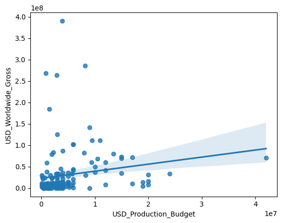

```python
sns.regplot(data=old_films,
            x='USD_Production_Budget',
            y='USD_Worldwide_Gross')
```

**Challenge**: Use Seaborn's `.regplot()` to show the scatter plot and linear regression line against the `new_films`.  
Style the chart

- Put the chart on a `'darkgrid'`.
- Set limits on the axes so that they don't show negative values.
- Label the axes on the plot "Revenue in \$ billions" and "Budget in \$ millions".
- Provide HEX colour codes for the plot and the regression line. Make the dots dark blue (#2f4b7c) and the line orange (#ff7c43).

Interpret the chart

- Do our data points for the new films align better or worse with the linear regression than for our older films?
- Roughly how much would a film with a budget of $150 million make according to the regression line?

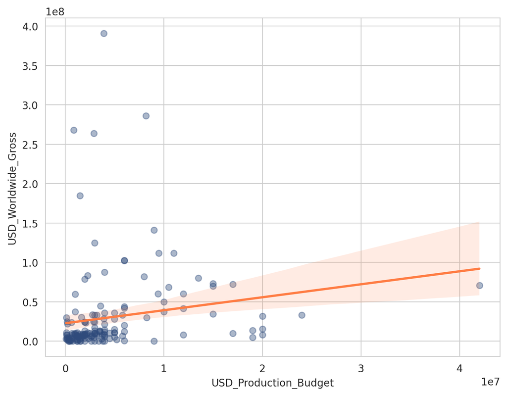

```python
plt.figure(figsize=(8,6), dpi=200)

with sns.axes_style('whitegrid'):
    ax = sns.regplot(data=old_films,
                     x='USD_Production_Budget',
                     y='USD_Worldwide_Gross',
                     color='#2f4b7c',
                     scatter_kws={'alpha': 0.4},
                     line_kws= {'color':'#ff7c43'})

plt.show()
```

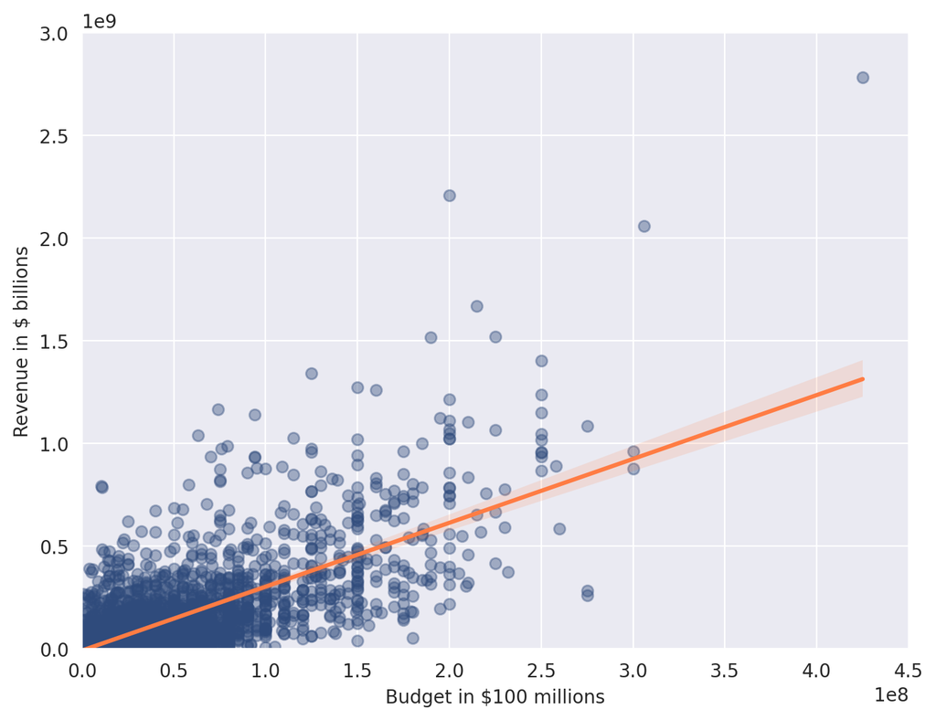

```python
plt.figure(figsize=(8,6), dpi=200)

with sns.axes_style('darkgrid'):
    ax = sns.regplot(data=data_clean,
                     x='USD_Production_Budget',
                     y='USD_Worldwide_Gross',
                     color='#2f4b7c',
                     scatter_kws={'alpha': 0.4},
                     line_kws={'color': '#ff7c43'})
    ax.set(ylim=(0, 3000000000),
         xlim=(0, 450000000),
         ylabel='Revenue in $ billions',
         xlabel='Budget in $100 millions')

plt.show()
```

# Run Your Own Regression with scikit-learn

$$ REV \hat ENUE = \theta _0 + \theta _1 BUDGET$$

```python
from sklearn.linear_model import LinearRegression
```

```python
regression = LinearRegression()
```

```python
x = pd.DataFrame(new_films, columns=['USD_Production_Budget'])
y = pd.DataFrame(new_films, columns=['USD_Worldwide_Gross'])
```

```python
regression.fit(x,y)
```

```
LinearRegression()
```

```python
regression.intercept_
```

```
array([-8650768.00661042])
```

```python
regression.coef_
```

```
array([[3.12259592]])
```

```python
regression.score(x,y)
```

```
0.5577032617720403
```

**Challenge**: Run a linear regression for the `old_films`. Calculate the intercept, slope and r-squared. How much of the variance in movie revenue does the linear model explain in this case?

```python
x = pd.DataFrame(old_films, columns=['USD_Production_Budget'])
y = pd.DataFrame(old_films, columns=['USD_Worldwide_Gross'])
```

```python
regression.fit(x,y)
```

```
LinearRegression()
```

```python
regression.intercept_
```

```
array([22821538.63508039])
```

```python
regression.coef_
```

```
array([[1.64771314]])
```

```python
regression.score(x,y)
```

```
0.02937258620576877
```

# Use Your Model to Make a Prediction

We just estimated the slope and intercept! Remember that our Linear Model has the following form:

$$ REV \hat ENUE = \theta _0 + \theta _1 BUDGET$$

**Challenge**: How much global revenue does our model estimate for a film with a budget of $350 million?

```python
budget = 350000000
```

```python
revenue_estimate = regression.intercept_[0] + regression.coef_[0,0] * budget
```

```python
revenue_estimate = round(revenue_estimate, -6)
```

```python
print(f'The estimate revenue is {revenue_estimate}')
```

```
The estimate revenue is 600000000.0
```